# Power analysis con tempi di reazione

mp

14/05/2024

## Studio di riferimento

L’esperimento si compone di due fattori sperimentali (*match* $\times$ *identity*) ciascuno con due livelli; i soggetti coinvolti sono 15, ad ognuno dei quali sono stati somministrati 200 trial, 50 per condizione.

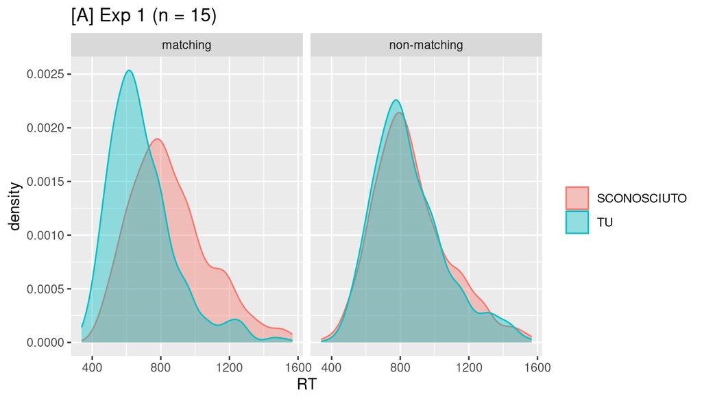

Per il nuovo studio si prende in considerazione la sola condizione di *matching* e si vuole confrontare un campione di controllo con soggetti di un campione target.

**Problema**: i soggetti target sono pochi (molta memoria).

Obiettivo della power è individuare quanti soggetti servono (per gruppo) tenendo conto che il numero di trial non può essere aumentato ulteriormente.

## Gamma distribution

Per modellare i RT utilizziamo la Gamma.

La distribuzione Gamma è definita con
$$\begin{eqnarray}\label{eq:dgamma1}
f(y|\alpha,\lambda) = \frac{1}{\Gamma(\alpha)} \lambda^{\alpha}
y^{\alpha-1} e^{-\lambda y}
\end{eqnarray}$$
con $y>0$, in cui $\alpha>0$ indica il parametro di shape e $\lambda>0$ il parametro di rate. La distribuzione ha valore atteso $E(y)=\alpha/\lambda$ e varianza $\mbox{Var}(Y)=\alpha/ \lambda^2$.

Il modello generativo dei dati è formalizzato nel seguente modo:
$$\begin{eqnarray}\label{eq:generativemodel}
\begin{array}{cr}
RT \sim \text{Gamma}(\alpha, \lambda) & \text{Modello dei dati
osservati}\\
\alpha & \text{Parametro di shape}\\
\lambda = \alpha / exp(\mu) & \text{Parametro di rate}\\
\mu = {\mathbf{X}\beta} & \text{Componente lineare}
\end{array}
\end{eqnarray}$$

Ovvero, i RT si distribuiscono secondo una funzione Gamma di parametri $\alpha$ (shape) e $\lambda$ (rate); $\lambda$ è dato dal rapporto $\alpha/exp(\mu)$ in cui $\mu$ è il valore atteso della componente lineare del modello, da cui si ricava: $E(y)=\alpha/\lambda = \alpha/(\alpha/exp(\mu)) = exp(\mu)$.

In sintesi: dobbiamo individuare i vettori di parametri $\mathbf{\beta}$ che producono le differenze di RT attese nelle varie condizioni sperimentali.

## Stime dei parametri sui dati osservati

**Importante** Utilizziamo i dati disponibili per valutare: 1) se la Gamma funziona sufficientemente bene; 2) per avere un’idea della variabilità individuale.

```r
> library( brms )
> fitRT <- brm( RT ~ identity + (1|ID),
+       data = subset( X, match == "matching"  & ACCURATEZZA == 1), family = "gamma", seed = SEED )
```

```
 Family: gamma
  Links: mu = log; shape = identity
Formula: RT ~ identity + (1 | ID)
   Data: subset(X, match == "matching" & ACCURATEZZA == 1) (Number of observations: 1350)
  Draws: 4 chains, each with iter = 2000; warmup = 1000; thin = 1;
         total post-warmup draws = 4000

Group-Level Effects:
~ID (Number of levels: 15)
              Estimate Est.Error l-95% CI u-95% CI Rhat Bulk_ESS Tail_ESS
sd(Intercept)     0.12      0.03     0.07     0.18 1.00      611     1148

Population-Level Effects:
           Estimate Est.Error l-95% CI u-95% CI Rhat Bulk_ESS Tail_ESS
Intercept     -0.16      0.03    -0.22    -0.09 1.00      639      998
identityTU    -0.22      0.01    -0.24    -0.19 1.00     3968     3012

Family Specific Parameters:
      Estimate Est.Error l-95% CI u-95% CI Rhat Bulk_ESS Tail_ESS
shape    16.50      0.63    15.26    17.73 1.00     3159     2670

Draws were sampled using sampling(NUTS). For each parameter, Bulk_ESS
and Tail_ESS are effective sample size measures, and Rhat is the potential
scale reduction factor on split chains (at convergence, Rhat = 1).
```

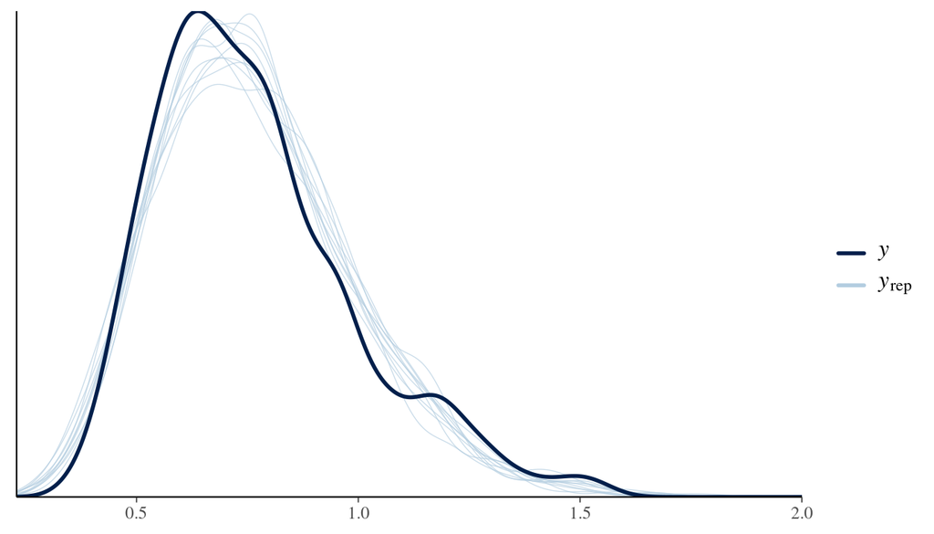

```r
> pp_check(fitRT)
```

## Effetti ipotizzati

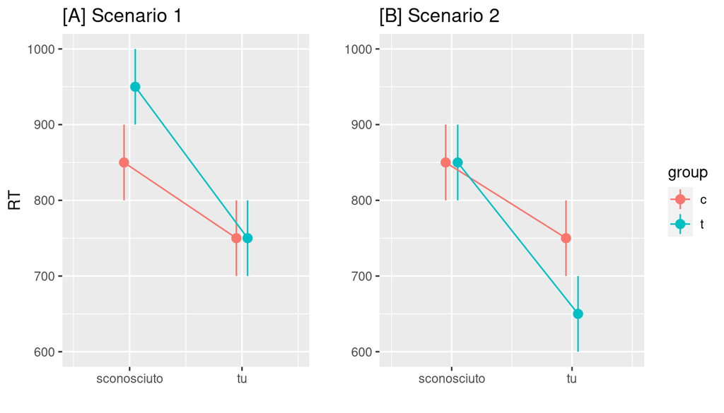

## Calcolo dei parametri

Per calcolare i parametri, utilizziamo la parte lineare del modello:

$$\begin{eqnarray}
\beta = \mu \mathbf{X}^{-1}
\end{eqnarray}$$

con la seguente funzione:

```r
> expected_pars_RT <- function(MU){
+
+   DESIGN <- expand.grid(
+     I = c("sconosciuto", "tu"),
+     G = c("control","target") )
+   DESIGN$MU <- MU
+   MM <- model.matrix( MU ~ I*G, data = DESIGN)
+
+   ETA <- matrix( log(MU/1000) )
+   DESIGN$BE <- solve( MM, ETA )
+   return(DESIGN)
+
+ }
>
> expected_pars_RT( c( 850, 750, 850, 650 ))$BE
```

```
                  [,1]
(Intercept) -0.1625189
Itu         -0.1251631
Gtarget      0.0000000
Itu:Gtarget -0.1431008
```

Per simulare RT coerenti con lo scenario 2 il modello sarà:

$$\begin{eqnarray}\label{eq:exp1simdata1}
\begin{array}{l}
\mu = (-0.16+\delta_i) -0.13 I + 0 G -0.14 IG\\
\delta \sim Normal( 0, \sigma_{\delta})
\\
\lambda = 16 / exp(\mu) \\
RT \sim Gamma( 16, \lambda) \end{array}
\end{eqnarray}$$
in cui $I \in \{0,1\}$ indica le due condizioni *sconosciuto*/*tu*, $G \in \{0,1\}$ i due gruppi – controllo e target – e $\delta$ rappresenta la variabilità dei soggetti intorno all’intercetta generale; per semplicità la assumiamo costante anche rispetto ai trials.

Come deviazione standard della variabilità individuale $\sigma_{\delta}$ aumentiamo leggermente il valore stimato empiricamente (0.12) a 0.15. Dal momento che anche la variabilità individuale incide sulla potenza, meno differenze tra soggetti implica più potenza, assumendo un maggior grado di differenza ci poniamo in una posizione più prudente.

## Prova di simulazione

Proviamo a generare un campione di 1000 soggetti (500 per gruppo) con 50 trial per condizione.

Stimiamo i parametri:

```
 Family: gamma
  Links: mu = log; shape = identity
Formula: RT ~ I * G + (1 | ID)
   Data: Z2 (Number of observations: 100000)
  Draws: 4 chains, each with iter = 5000; warmup = 2500; thin = 1;
         total post-warmup draws = 10000

Group-Level Effects:
~ID (Number of levels: 1000)
              Estimate Est.Error l-95% CI u-95% CI Rhat Bulk_ESS Tail_ESS
sd(Intercept)     0.14      0.00     0.14     0.15 1.00      735     1526

Population-Level Effects:
            Estimate Est.Error l-95% CI u-95% CI Rhat Bulk_ESS Tail_ESS
Intercept      -0.15      0.01    -0.16    -0.14 1.01      395      697
Itu            -0.12      0.00    -0.13    -0.12 1.00    14533     8278
Gtarget        -0.00      0.01    -0.02     0.01 1.02      360      912
Itu:Gtarget    -0.14      0.00    -0.14    -0.13 1.00    15819     7539

Family Specific Parameters:
      Estimate Est.Error l-95% CI u-95% CI Rhat Bulk_ESS Tail_ESS
shape    16.06      0.07    15.93    16.20 1.00    18398     7175

Draws were sampled using sampling(NUTS). For each parameter, Bulk_ESS
and Tail_ESS are effective sample size measures, and Rhat is the potential
scale reduction factor on split chains (at convergence, Rhat = 1).
```

Visualizziamo i RT medi (attesi) per condizione:

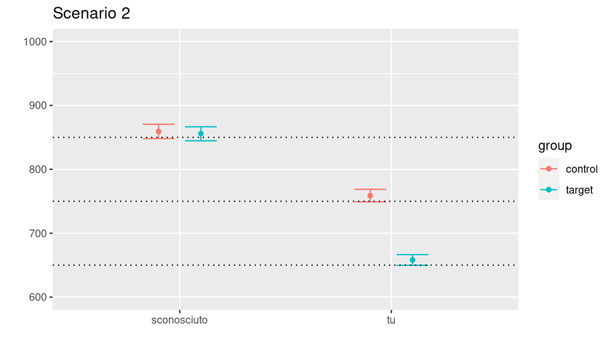

## Power analysis

Scegliamo 5 numerosità campionarie (per gruppo): $n = 10, 15, 20, 25, 30$ e, per ciascuna di esse, ripetiamo per 600 volte il seguente algoritmo:

1. Simuliamo un set di dati con $n$ soggetti per gruppo e 50 trials per condizione: ogni soggetto ha 100 osservazioni, 50 nella condizione *sconosciuto* e 50 nella condizione *tu*.
2. Stimiamo i parametri del modello utilizzando le seguenti prior

```
                 prior     class        coef
1   student_t(3, 0, 1) Intercept
2 student_t(3, 0, .04)         b         Itu
3 student_t(3, 0, .04)         b     Gtarget
4 student_t(3, 0, .04)         b Itu:Gtarget
5   student_t(3, 0, 2)        sd
6        gamma(17, 17)     shape
```

Si tratta di prior scettiche, sulla base delle quali, assumiamo che, con una probabilità di 90%, i coefficienti di regressione cadano nell’intervallo $[-0.09, 0.09]$. Questo intervallo, che possiamo definire *null interval*, definisce in pratica i valori per i quali gli effetti si considerano sostanzialmente nulli. Per l’intercetta invece la prior è più ampia, si assume, con la stessa probabilità, che i valori cadano nell’intervallo $[-2.35, 2.35]$; ricordiamo che non ci interessa fare la power sull’intercetta.

3. Per ciascun parametro calcoliamo gli intervalli di credibilità al 90% e 80% (*Credible Interval*, CI) ovvero gli estremi che contengono rispettivamente queste due porzioni di distribuzioni a posteriori. La scelta dei valori 80% e 90% è giustificata dal limite di soggetti che si potranno reclutare e dal fatto che gli effetti attesi sono piuttosto piccoli.

Per calcolare la potenza contiamo quante volte l’intervallo è completamente fuori dal range $[-0.09, 0.09]$. In pratica, la potenza, per ogni parametro e numerosità, viene stimata come rapporto tra il numero di volte in cui l’IC è fuori dall’intervallo *nullo* ed il totale di iterazioni per numerosità (600). Dal momento che gli IC 80% sono più stretti di quelli 90%, con i primi ci attendiamo un livello di potenza maggiore.

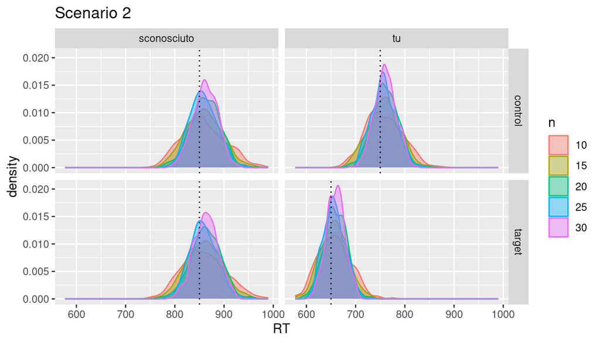

E quindi le curve di potenza per i $\beta$ del modello:

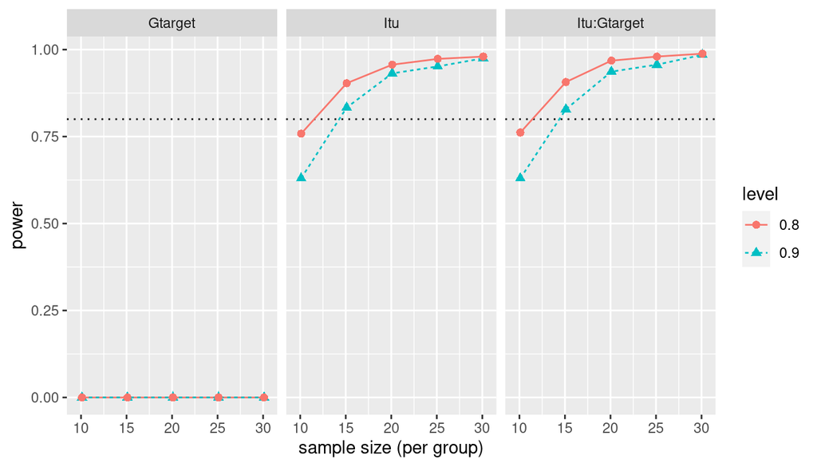